# foodb analysis

2025-02-19

Packages inladen

```r
library(dplyr)
```

```r
library(tidyr)
library(ggplot2)
library(compositions)
library(ggrepel)
library(broom)
```

Data inladen

```r
foodb <- read.csv("C:\\Users\\bramd_finhsgu\\OneDrive - UGent\\Thesis\\Thesis_scripts\\Masterthesis_2425_Bram_Duthoo\\scripts\\foodb\\foodb_data.csv", header = TRUE)

foodb_nutrient <- foodb %>%
  filter(source_type == "Nutrient") %>%
  select(-source_type)

foodb_compound <- foodb %>%
  filter(source_type == "Compound") %>%
  select(-source_type)
```

foodb_compound omzetten in dataframe voor verdere bewerkingen + aanmaken food & source id lookup tabel voor interpretatie resultaten.

```r
# Stap 1: Creëer de eerste dataframe
recepten <- foodb_compound %>%
  select(orig_food_id, source_id, converted_value) %>%
  pivot_wider(names_from = source_id, values_from = converted_value, values_fn = list(converted_value = mean), values_fill = 0)

# Stap 2: Creëer de tweede dataframe
food_id_lookup <- foodb_compound %>%
  select(orig_food_id, food_id, orig_food_common_name) %>%
  distinct() %>%
  arrange(orig_food_id)

# Stap 3: Creëer de derde dataframe
source_id_lookup <- foodb_compound %>%
  select(source_id, orig_source_name, subklass) %>%
  distinct() %>%
  arrange(source_id)

# Toon de dataframes
print(recepten)
```

```
## # A tibble: 450 × 128
##    orig_food_id `21594` `21595` `1131` `753` `3513` `13393` `13831` `14616`
##           <int>   <dbl>   <dbl>  <dbl> <dbl>  <dbl>   <dbl>   <dbl>   <dbl>
##  1          551    9090   5592.      0     0   3400   55500   0.042       0
##  2          436    6495   4098       0     0    900   65400   0.04        0
##  3          437   12400   7595       0     0   1000   53800   0.036       0
##  4          438   11700   7205       0     0   1000   54200   0.034       0
##  5          432    5605   3447       0     0   1000   66300   0.013       0
##  6          430    8995   5540       0     0   1000   59500   0.025       0
##  7          422    2720   1690.      0     0   1000   71000   0.003       0
##  8          428    2690   1653.      0     0   1100   72700   0           0
##  9          440   12700   7805       0     0   1000   52800   0.038       0
## 10          439   12600   7752.      0     0   1000   53800   0.037       0
## # ℹ 440 more rows
## # ℹ 119 more variables: `21596` <dbl>, `12735` <dbl>, `12814` <dbl>,
## #   `565` <dbl>, `12360` <dbl>, `8417` <dbl>, `12163` <dbl>, `1014` <dbl>,
## #   `574` <dbl>, `8323` <dbl>, `14513` <dbl>, `14507` <dbl>, `13267` <dbl>,
## #   `1224` <dbl>, `21468` <dbl>, `3524` <dbl>, `3522` <dbl>, `3514` <dbl>,
## #   `3519` <dbl>, `3521` <dbl>, `16258` <dbl>, `3583` <dbl>, `3730` <dbl>,
## #   `3636` <dbl>, `3637` <dbl>, `3517` <dbl>, `13403` <dbl>, `13447` <dbl>, …
```

```r
print(food_id_lookup)
```

```
##     orig_food_id food_id
## 1            111     506
## 2            199     506
## 3            200     506
## 4            201     506
## 5            202     506
## 6            284     549
## 7            285     549
## 8            286     549
## 9            287     549
## 10           322     506
## 11           323     506
## 12           324     549
## 13           371     549
## 14           372     549
```

[output cut: 889 more lines]

```r
print(source_id_lookup)
```

```
##     source_id                               orig_source_name
## 1         446                                       Tyrosine
## 2         446                                     L-Tyrosine
## 3         455                                    Theobromine
## 4         465                                         Valine
## 5         465                                       L-Valine
## 6         474                                         Lysine
## 7         484                                        Glycine
## 8         556                                        Alanine
## 9         556                                      L-Alanine
## 10        565                               Vitamin E, total
## 11        565                    Vitamin E, alpha tocopherol
## 12        565                   Vitamin E (alpha-tocopherol)
## 13        565                               Vitamin E, added
## 14        565                               alpha-Tocopherol
```

[output cut: 465 more lines]

Data verkenning source_ids (alle verschillende compounds), distributie over alle food_id’s (~recepten) indien sample size groot/relevant genoeg is. Grens ligt momenteel op 100, handmatig gekozen om veel recepten, met weinig nulwaardes, over te houden. Echter geen volledig correcte manier van compounds verwijderen, idee: a) alle compounds met in elk recept een nulwaarde verwijderen. b) Belang compounds bepalen binnenin een food_id (diersoort). d.w.z. dat compounds die binnenin een food_id voor bijna elk recept voorkomen belangrijk zijn om te behouden, ook al is het totaal aantal nulwaarden over alle food_id’s heel groot. Compounds die over elke food_id een verdeling hebben van niet nul-waarden % die onder een drempel ligt worden verwijderd.

```r
# Bereken percentage nulwaarden per orig_food_id
percentage_nulwaarden <- recepten %>%
  mutate(total_values = rowSums(. != 0),  # Tel niet-nulwaarden
         total_columns = ncol(.) - 1,  # Aantal bron ID's (kolommen) minus orig_food_id
         percentage_nul = (total_columns - total_values) / total_columns * 100) %>%
  select(orig_food_id, percentage_nul)

print(percentage_nulwaarden)
```

```
## # A tibble: 450 × 2
##    orig_food_id percentage_nul
##           <int>          <dbl>
##  1          551           43.3
##  2          436           45.7
##  3          437           43.3
##  4          438           43.3
##  5          432           43.3
##  6          430           43.3
##  7          422           43.3
##  8          428           48.8
##  9          440           43.3
## 10          439           43.3
## # ℹ 440 more rows
```

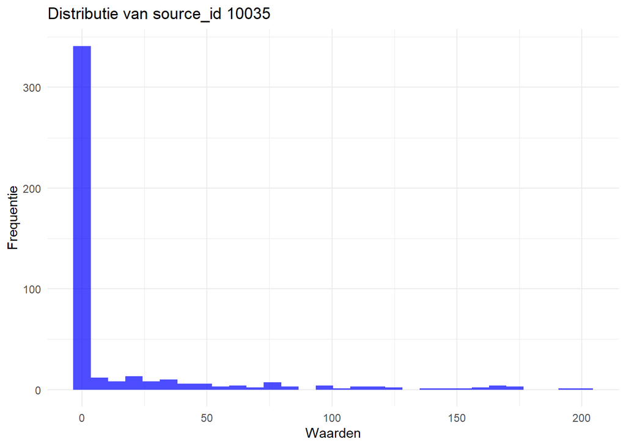

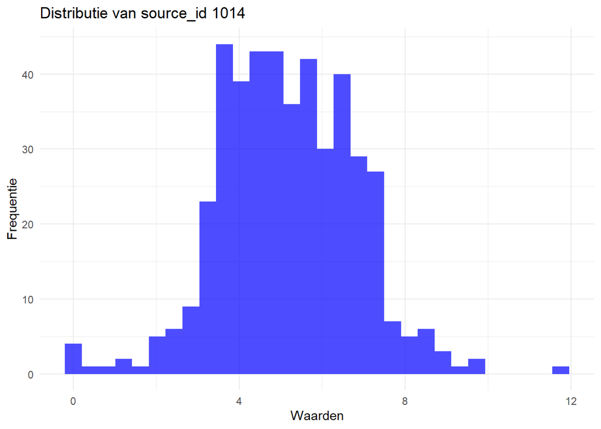

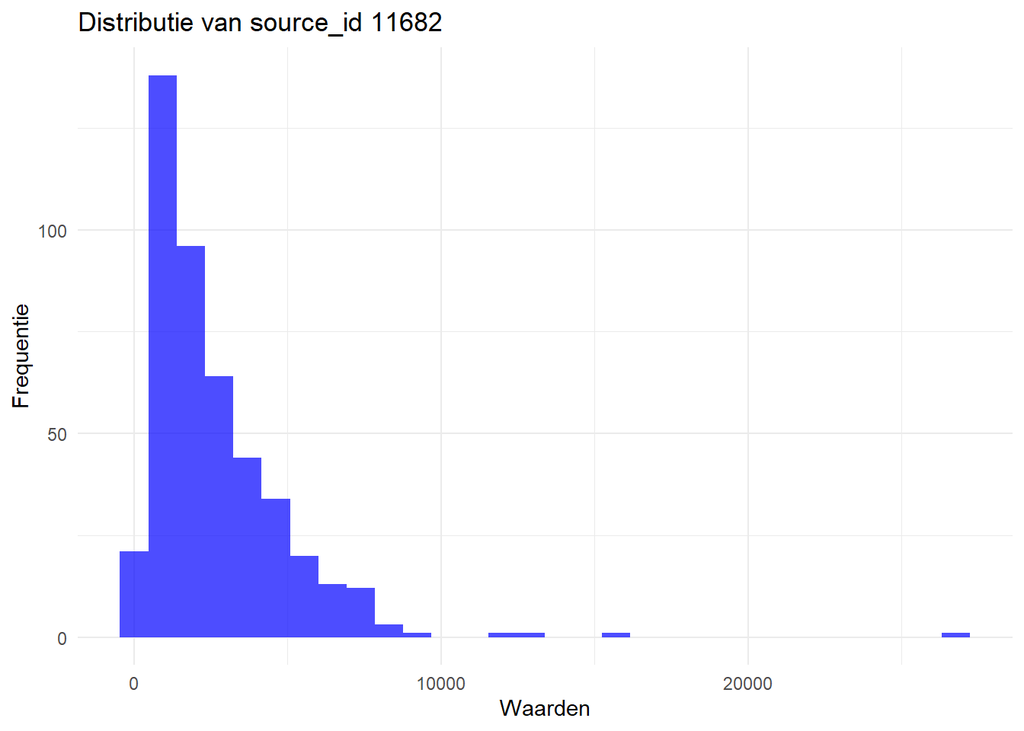

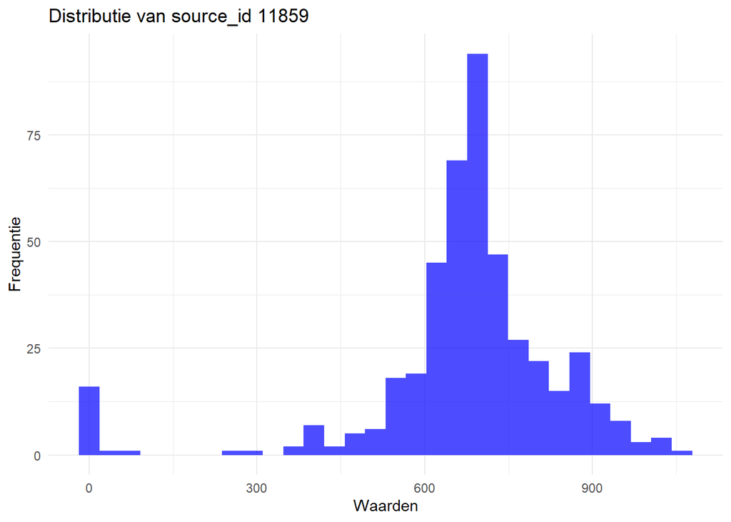

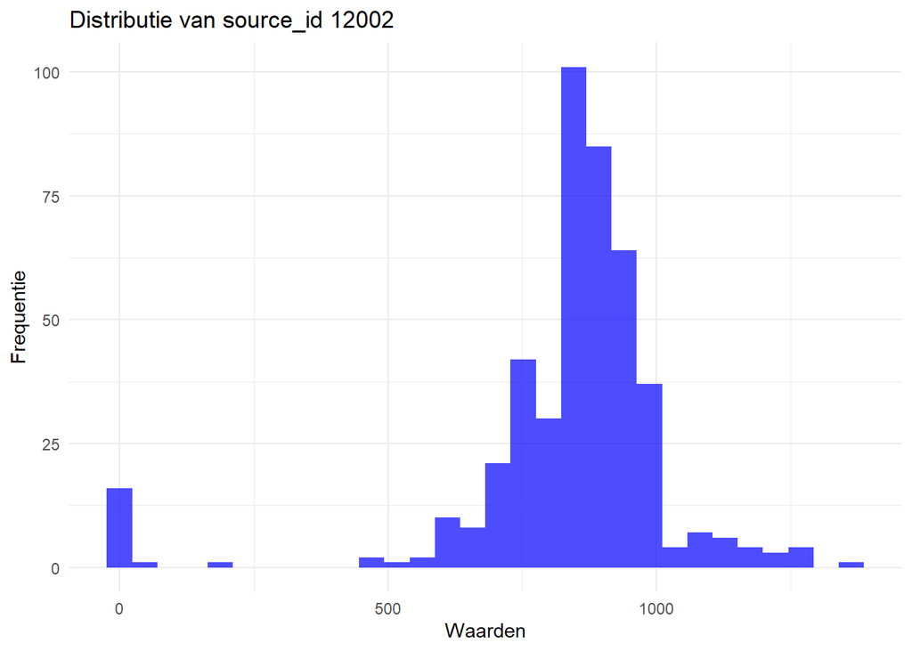

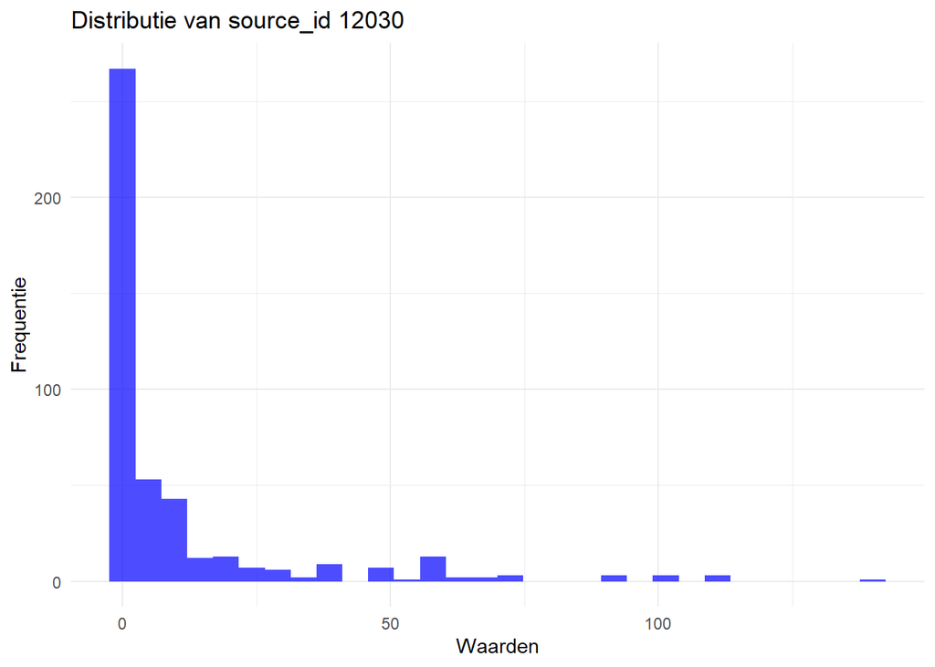

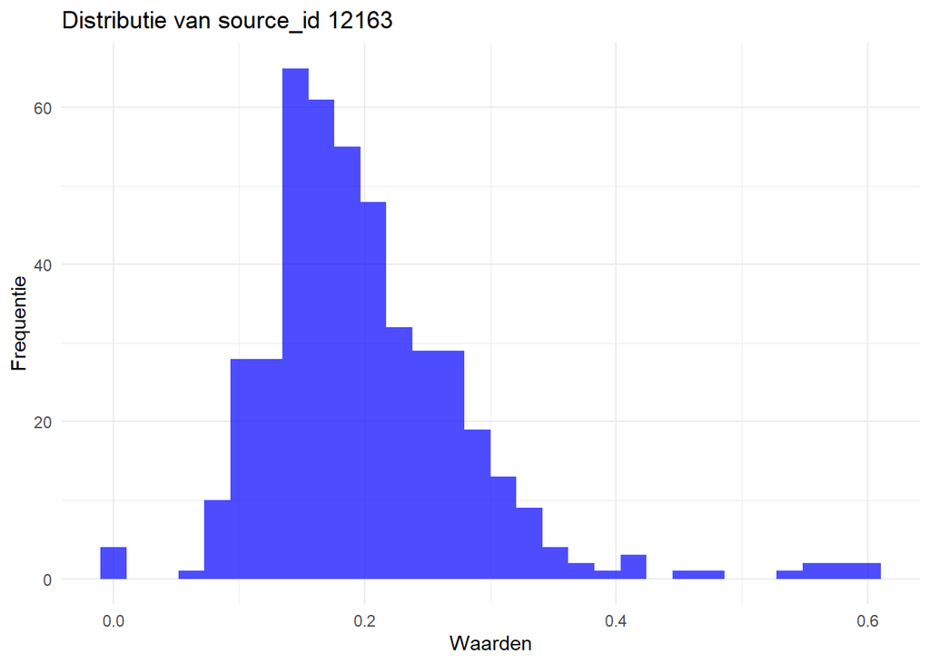

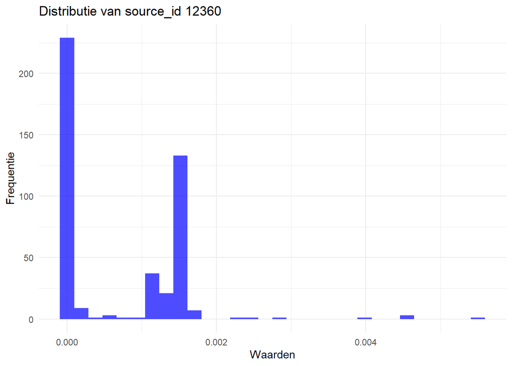

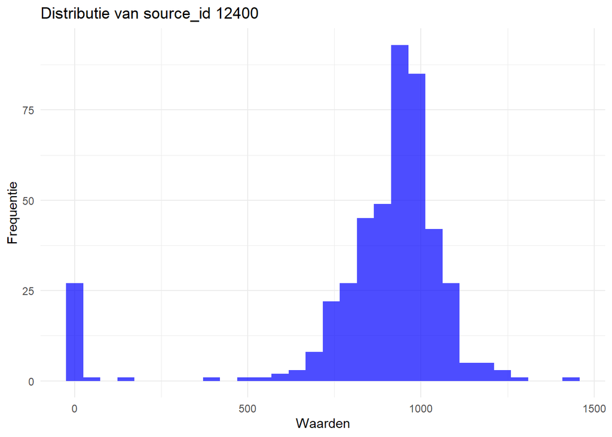

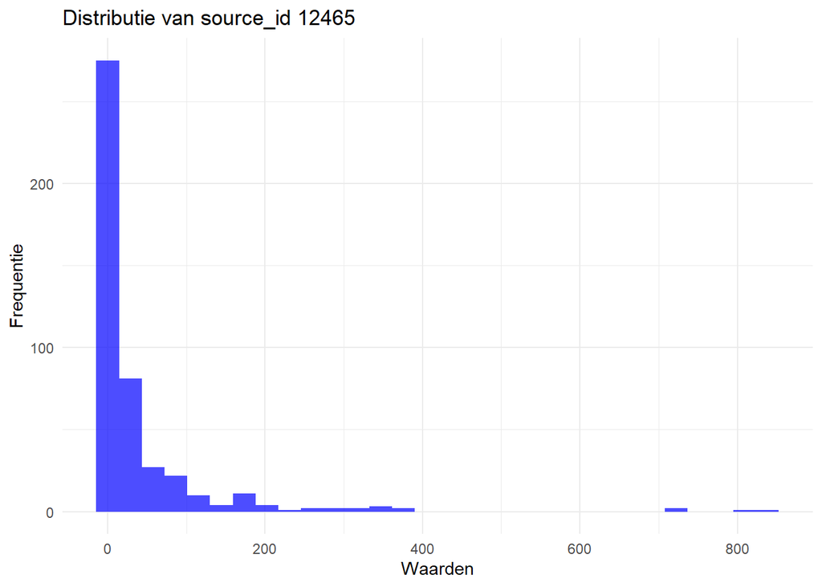

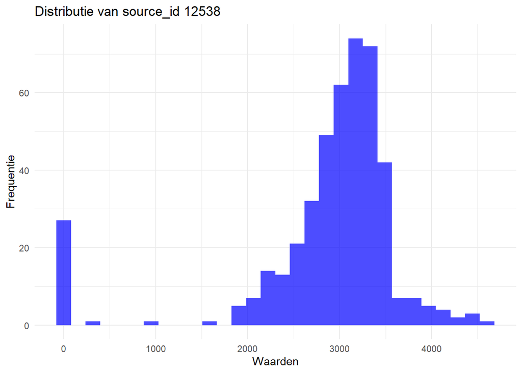

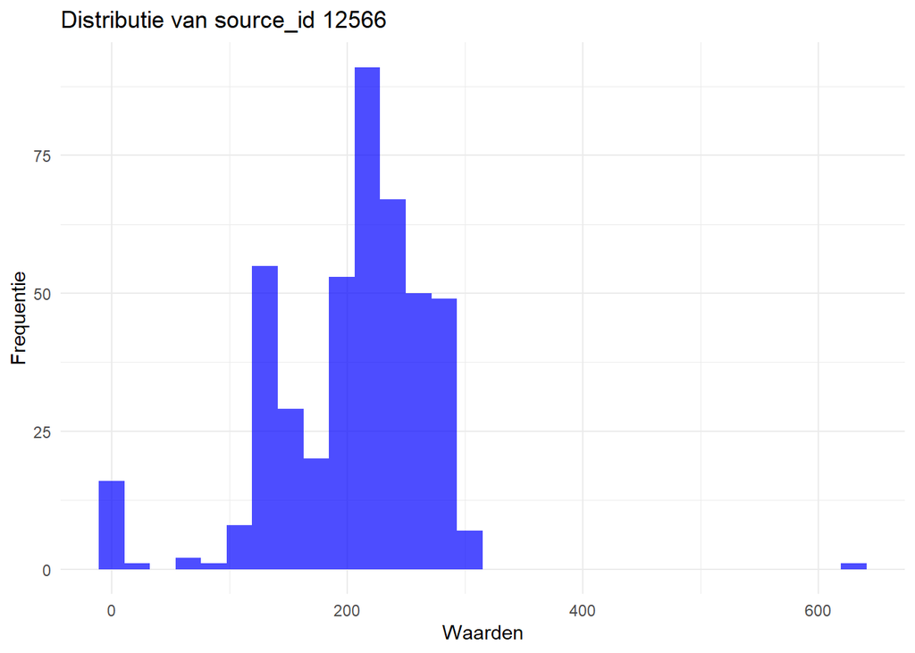

[47 more figures not shown]

```r
# Groeperen en tellen van niet-nulwaarden per source_id
recepten_long <- recepten %>%
  pivot_longer(-orig_food_id, names_to = "source_id", values_to = "value") %>%
  group_by(source_id) %>%
  summarise(n_niet_nul = sum(value != 0),
            n_nul = sum(value == 0),
            .groups = "drop") %>%
  mutate(is_groot_genoeg = n_niet_nul >= 100)

# Split de data op basis van het aantal niet-nulwaarden
source_id_groot_genoeg <- recepten_long %>%
  filter(is_groot_genoeg)

source_id_te_weinig <- recepten_long %>%
  filter(!is_groot_genoeg)

recepten_long_full <- recepten %>%
  pivot_longer(-orig_food_id, names_to = "source_id", values_to = "value")

# Distributie voor source_id's met 25+ niet-nulwaarden
for (id in source_id_groot_genoeg$source_id) {
  p <- ggplot(recepten_long_full %>%
                filter(source_id == id),
              aes(x = value)) +
    geom_histogram(bins = 30, fill = "blue", alpha = 0.7) +
    ggtitle(paste("Distributie van source_id", id)) +
    xlab("Waarden") +
    ylab("Frequentie") +
    theme_minimal()

  print(p)  # Dit zorgt ervoor dat de plots correct getoond worden
}
```

```r
# Statistieken voor source_id's met minder dan 25 niet-nulwaarden
stats_te_weinig <- source_id_te_weinig %>%
  mutate(mean_nulwaarden = n_nul / (n_nul + n_niet_nul) * 100)

# Bereken statistieken met de correcte dataset recepten_long_full
summary_stats <- recepten_long_full %>%
  filter(source_id %in% source_id_te_weinig$source_id) %>%
  group_by(source_id) %>%  # Groepeer per source_id
  summarise(
    mean_value = mean(value, na.rm = TRUE),
    median_value = median(value, na.rm = TRUE),
    q25 = quantile(value, 0.25, na.rm = TRUE),
    q75 = quantile(value, 0.75, na.rm = TRUE),
    .groups = "drop"  # Zorgt ervoor dat het resultaat geen gegroepeerd dataframe is
  )

print(stats_te_weinig)
```

```
## # A tibble: 68 × 5
##    source_id n_niet_nul n_nul is_groot_genoeg mean_nulwaarden
##    <chr>          <int> <int> <lgl>                     <dbl>
##  1 10326              2   448 FALSE                      99.6
##  2 1128               2   448 FALSE                      99.6
##  3 1131               0   450 FALSE                     100
##  4 1145               0   450 FALSE                     100
##  5 11678             93   357 FALSE                      79.3
##  6 11820             93   357 FALSE                      79.3
##  7 11875             30   420 FALSE                      93.3
##  8 1193               0   450 FALSE                     100
##  9 12022              0   450 FALSE                     100
## 10 12065              0   450 FALSE                     100
## # ℹ 58 more rows
```

```r
print(summary_stats)
```

```
## # A tibble: 68 × 5
##    source_id mean_value median_value   q25   q75
##    <chr>          <dbl>        <dbl> <dbl> <dbl>
##  1 10326          2.89             0     0     0
##  2 1128           2.89             0     0     0
##  3 1131           0                0     0     0
##  4 1145           0                0     0     0
##  5 11678        102.               0     0     0
##  6 11820          0.145            0     0     0
##  7 11875          8.11             0     0     0
##  8 1193           0                0     0     0
##  9 12022          0                0     0     0
## 10 12065          0                0     0     0
## # ℹ 58 more rows
```

Visualizatie van het aantal recepten dat overeenkomt met het minimum aantal niet-nulwaarden %. Hulpmiddel bij evenwicht zoeken tussen genoeg recepten behouden en zo min mogelijk nulwaarden (probleem voor log-transformaties).

```r
# Stap 1: Filteren van source_id's met genoeg niet-nulwaarden
groot_genoeg_ids <- source_id_groot_genoeg$source_id  # Veronderstel dat dit de correcte bron is

# Stap 2: Bereken percentage niet-nulwaarden per orig_food_id
percentage_niet_nul <- recepten_long_full %>%
  filter(source_id %in% groot_genoeg_ids) %>%  # Beperk tot de relevante source_id's
  group_by(orig_food_id) %>%
  summarise(
    total_values = n(),  # Aantal componenten (source_id's)
    niet_nul_values = sum(value != 0, na.rm = TRUE),  # Aantal niet-nulwaarden
    percentage_niet_nul = niet_nul_values / total_values * 100,  # Percentage niet-nulwaarden
    .groups = "drop"
  )

# Stap 2: Groepeer per percentage_niet_nul en tel het aantal orig_food_ids per groep
cumulative_distribution <- percentage_niet_nul %>%
  group_by(percentage_niet_nul) %>%
  summarise(count = n(), .groups = "drop") %>%  # Tel het aantal orig_food_ids per % niet-nulwaarde
  arrange(desc(percentage_niet_nul)) %>%  # Sorteer van hoog naar laag
  mutate(cumulative_count = cumsum(count)) %>%  # Cumulatieve som nemen
  mutate(cumulative_percentage = cumulative_count / sum(count) * 100)  # Omzetten naar %

# Stap 3: Debugging - Check of cumulatieve verdeling correct werkt
print(head(cumulative_distribution))  # Bekijk de eerste rijen om te zien of data klopt
```

```
## # A tibble: 6 × 4
##   percentage_niet_nul count cumulative_count cumulative_percentage
##                 <dbl> <int>            <int>                 <dbl>
## 1               100      24               24                  5.33
## 2                98.3     3               27                  6
## 3                96.6     4               31                  6.89
## 4                94.9    56               87                 19.3
## 5                93.2    21              108                 24
## 6                91.5    19              127                 28.2
```

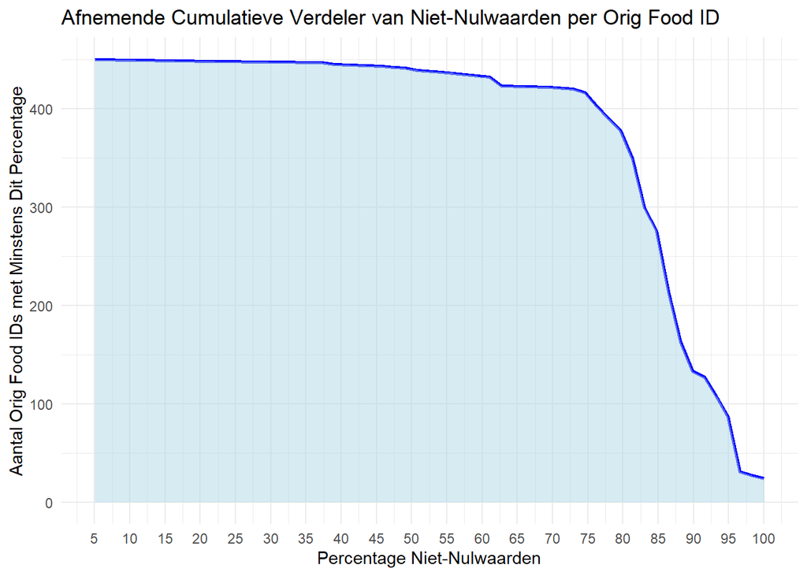

```r
# Stap 4: Visualiseer de cumulatieve verdeling
ggplot(cumulative_distribution, aes(x = percentage_niet_nul, y = cumulative_count)) +
  geom_line(color = "blue", size = 1) +
  geom_area(fill = "lightblue", alpha = 0.5) +
  scale_x_continuous(breaks = seq(0, 100, by = 5)) +  # X-as van 0% tot 100%
  labs(
    title = "Afnemende Cumulatieve Verdeler van Niet-Nulwaarden per Orig Food ID",
    x = "Percentage Niet-Nulwaarden",
    y = "Aantal Orig Food IDs met Minstens Dit Percentage"
  ) +
  theme_minimal()
```

Resultaat voordien toonde aan dat 80% een goed evenwichtspunt is. Hieronder is een functie die het aantal recepten dat overeenkomt met een minimum % van niet nulwaarden = 80%, in functie toont van hoe streng compounds worden weggefilterd (zie n_niet_nul bij bereken van alle distributies).

```r
library(tidyverse)
```

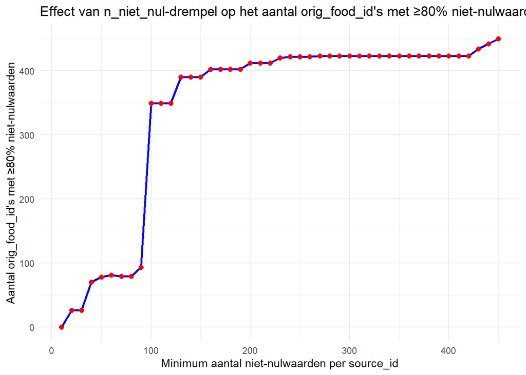

```r
# Stap 1: Groeperen en tellen van niet-nulwaarden per source_id
recepten_long <- recepten %>%
  pivot_longer(-orig_food_id, names_to = "source_id", values_to = "value") %>%
  group_by(source_id) %>%
  summarise(n_niet_nul = sum(value != 0),  # Tel aantal niet-nulwaarden
            .groups = "drop")

# Stap 2: Genereer een reeks drempelwaarden voor n_niet_nul
drempels <- seq(10, max(recepten_long$n_niet_nul), by = 10)

# Stap 3: Iteratief filteren en opslaan hoeveel orig_food_id's een niet-nulpercentage ≥ 80% behouden
resultaten <- map_dfr(drempels, function(drempel) {

  # Filter source_id's met minstens 'drempel' niet-nulwaarden
  relevante_source_ids <- recepten_long %>%
    filter(n_niet_nul >= drempel) %>%
    pull(source_id)

  # Filter recepten_long_full om alleen relevante source_id's te behouden
  percentage_niet_nul <- recepten %>%
    pivot_longer(-orig_food_id, names_to = "source_id", values_to = "value") %>%
    filter(source_id %in% relevante_source_ids) %>%
    group_by(orig_food_id) %>%
    summarise(
      total_values = n(),
      niet_nul_values = sum(value != 0, na.rm = TRUE),
      percentage_niet_nul = niet_nul_values / total_values * 100,
      .groups = "drop"
    )

  # Bepaal hoeveel orig_food_id's nog steeds een niet-nulpercentage ≥ 80% hebben
  aantal_boven_80 <- sum(percentage_niet_nul$percentage_niet_nul >= 80)

  tibble(n_niet_nul_drempel = drempel, aantal_orig_food_boven_80 = aantal_boven_80)
})

# Stap 4: Visualiseer het effect van de drempel op het aantal orig_food_id's met ≥80% niet-nulwaarden
ggplot(resultaten, aes(x = n_niet_nul_drempel, y = aantal_orig_food_boven_80)) +
  geom_line(color = "blue", size = 1) +
  geom_point(color = "red", size = 2) +
  labs(
    title = "Effect van n_niet_nul-drempel op het aantal orig_food_id's met ≥80% niet-nulwaarden",
    x = "Minimum aantal niet-nulwaarden per source_id",
    y = "Aantal orig_food_id's met ≥80% niet-nulwaarden"
  ) +
  theme_minimal()
```

Data filteren op basis van vorige resultaten voor outlier detecte en PCA. Nog eens orig_food_id filter nakijken in vscode script aangezien er nog sommige ongewenste id’s doorkomen. Herbekijken na gebruik van andere source_id filtering.

```r
extra_ids <- c("10005", "10102", "36014", "36015", "36016", "36017", "36018", "36019", "36020", "36021",
               "36022", "36023", "36024", "13000", "13047", "17271", "17222", "10100", "10174", "13097",
               "13227", "13976", "13978", "17099", "17107", "17113", "17119", "17125", "17131", "17137",
               "17140", "17278", "23513", "13095", "13284", "13147", "13149", "13339", "17128", "17276",
               "13838", "13841", "13844", "13847", "13859", "23623", "322", "323", "428", "13023",
               "10072", "10121", "10187", "10219", "10228", "17110", "17142")  # Voeg hier je specifieke ID's toe

selected_orig_food_ids <- percentage_niet_nul %>%
  filter(percentage_niet_nul >= 79 | orig_food_id %in% extra_ids) %>%
  pull(orig_food_id)  # Haal de waarden op als een vector

# Stap 2: Filter recepten_long_full op deze orig_food_id's en groot_genoeg_ids
FOODB_MEAT <- recepten_long_full %>%
  filter(orig_food_id %in% selected_orig_food_ids & source_id %in% groot_genoeg_ids)
```

```r
# Stap 1: Data omzetten naar brede vorm (compositie per orig_food_id)
foodb_wide <- FOODB_MEAT %>%
  pivot_wider(names_from = source_id, values_from = value, values_fill = 0) %>%
  column_to_rownames("orig_food_id")  # Zet orig_food_id als rijnaam

# Stap 2: Vervang nullen door epsilon (klein getal om logproblemen te vermijden)
epsilon <- 1e-6
foodb_no_zeros <- foodb_wide %>%
  mutate(across(everything(), ~ ifelse(. == 0, epsilon, .)))

# Stap 3: Normaliseren (compositiesommen moeten gelijk zijn aan 1)
foodb_composition <- foodb_no_zeros %>%
  mutate(across(everything(), ~ . / rowSums(foodb_no_zeros, na.rm = TRUE)))

# Stap 4: ILR-transformatie uitvoeren
foodb_ilr <- compositions::ilr(foodb_composition)
```

Mahalanobis-afstanden & PCA hebben multivariate normaliteit als voorwaarde, deze voorwaarde moet beter worden nagegaan om geloofwaardigheid resultaten in te schatten.

```r
# Stap 1: Normaliteitstest uitvoeren op ILR-getransformeerde data
foodb_ilr_df <- as.data.frame(foodb_ilr)

normality_results <- foodb_ilr_df %>%
  # Gebruik reframe() om een data frame met meerdere waarden per kolom te retourneren
  reframe(across(everything(), ~ {
    shapiro_test <- shapiro.test(.)  # Voer de Shapiro-test uit
    data.frame(statistic = shapiro_test$statistic, p_value = shapiro_test$p.value)
  })) %>%
  pivot_longer(cols = everything(), names_to = "compound", values_to = "measure") %>%
  unnest(cols = measure)  # Maak de data frame breed

# Print resultaten
print(normality_results)
```

```
## # A tibble: 58 × 3
##    compound statistic  p_value
##    <chr>        <dbl>    <dbl>
##  1 V1          0.0841 3.50e-41
##  2 V2          0.839  1.22e-20
##  3 V3          0.281  7.09e-38
##  4 V4          0.700  3.97e-27
##  5 V5          0.920  1.80e-14
##  6 V6          0.941  3.76e-12
##  7 V7          0.798  7.30e-23
##  8 V8          0.860  2.91e-19
##  9 V9          0.817  6.58e-22
## 10 V10         0.817  6.69e-22
## # ℹ 48 more rows
```

```r
# Stap 5: Outlierdetectie met Mahalanobis-afstanden
mahal_distances <- mahalanobis(foodb_ilr, colMeans(foodb_ilr, na.rm = TRUE), cov(foodb_ilr, use = "pairwise.complete.obs"))
threshold <- qchisq(0.975, df = ncol(foodb_ilr))  # 97.5% grenswaarde
outliers <- which(mahal_distances > threshold)

# Lijst van outliers
list_of_outliers <- rownames(foodb_ilr)[outliers]
print("Outliers gevonden op basis van Mahalanobis-afstanden:")
```

```
## [1] "Outliers gevonden op basis van Mahalanobis-afstanden:"
```

```r
print(list_of_outliers)
```

```
##  [1] "551"   "436"   "428"   "199"   "423"   "425"   "371"   "381"   "543"
## [10] "284"   "286"   "5028"  "928"   "5004"  "373"   "322"   "323"   "324"
## [19] "111"   "7029"  "7030"  "10002" "10005" "10008" "10028" "10056" "10088"
## [28] "10100" "10102" "10105" "10121" "10174" "10192" "10946" "10948" "10957"
## [37] "10961" "10971" "10972" "10973" "13000" "13023" "13047" "13227" "13339"
## [46] "13342" "13498" "13864" "13976" "13978" "17222" "17271" "17276" "17278"
## [55] "23230" "23231" "23232" "23513" "23557" "23562" "23616" "36013" "36014"
## [64] "36015" "36016" "36017" "36019" "36021" "36022" "36023"
```

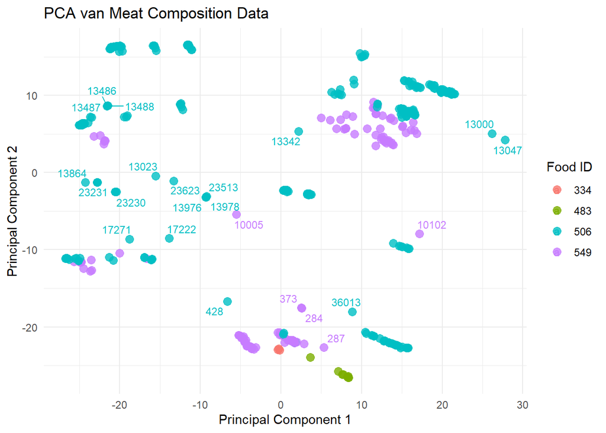

```r
# Stap 6: PCA uitvoeren op ILR-getransformeerde data
pca_model <- prcomp(foodb_ilr, scale. = FALSE)

pca_df <- as.data.frame(pca_model$x) %>%
  rownames_to_column("orig_food_id") %>%
  mutate(orig_food_id = as.character(orig_food_id)) %>%  # Zorg dat het character is
  left_join(food_id_lookup %>% mutate(orig_food_id = as.character(orig_food_id)), by = "orig_food_id")  # Voeg food_id toe voor kleur

# Stap 8: PCA plotten (kleur per food_id)
ggplot(pca_df, aes(x = PC1, y = PC2, color = as.factor(food_id), label = orig_food_id)) +
  geom_point(size = 3, alpha = 0.8) +
  geom_text_repel(size = 3) +
  labs(title = "PCA van Meat Composition Data",
       x = "Principal Component 1",
       y = "Principal Component 2",
       color = "Food ID") +
  theme_minimal()
```

Food ID 334 = kip, 483 = schaap, 506 = rund, 549 = varken.